# Assignment 1: Planetary Motion with `Vec3D`

**6EMA02 Particle-based Simulations, 2026-2027 edition** N-body gravity in C · integrators · conservation · a real asteroid

## How this assignment is assessed: read this first

This notebook is both the assignment text and your report. Task cells (like this one) are the assignment text and are marked read-only. Jupyter enforces that; some editors (VS Code among them) do not, so simply leave them untouched either way: hand-ins are checked against the released notebook, and modified task cells are flagged. You write your answers in the cells below each task and hand in this same notebook, **executed**, together with an HTML export, your code, and the data files the notebook loads (layout at the end of this notebook).

Your report is **not graded on its content**. Its result is determined in the individual oral examination at the end of the quartile: the exam is a conversation about *your* code and *your* results, with this notebook on screen. Write it as your defence dossier: concise, bullet answers are fine, every claim something you can stand behind. A report you never hand in scores 0 for its weight in the final grade; a handed-in report's result *is* your oral grade.

**AI and sources.** You may use AI assistants (ChatGPT, Claude, Copilot, …) freely in this course, for code, analysis, and text. Declare the use briefly in the *Sources* section below, along with any other external sources: anything in your submission (code, text, data, results) that your group did not produce itself. Declared sources are never penalised: nobody grades the text of your report or the style of your code. The oral examination assesses what *you* understand about the simulation you hand in. Anything in your submission is fair game, and "we didn't write that part" is not an available answer. Presenting undeclared external work as your own is academic misconduct and is treated as such.

## Group

- **Group ID:** group_A1_12
- **Members:** Tomas Dadikozyan (1959123), Paolo Zichella (2376822)

## Setting up your working environment

You need two toolchains: a C compiler for the simulation, and Python with Jupyter for the analysis in this notebook.

**C compiler.** Linux and macOS have `gcc` (or `clang` aliased to it). On Windows, install MSYS2 and use its `gcc`, or work inside WSL. Check with `gcc --version`.

**Python.** Work in a virtual environment so this course cannot break your other Python installations. From the directory holding this notebook, with `requirements.txt` (Files ▸ Assignments) next to it:

```
python3 -m venv pbs-env
source pbs-env/bin/activate          # Windows: pbs-env\Scripts\activate
pip install -r requirements.txt
jupyter lab
```

That installs NumPy, SciPy, matplotlib, pandas, Jupyter, and the two helper packages used below. Every session afterwards starts with the `activate` line. In Jupyter or VS Code, make sure the notebook's kernel is the `pbs-env` one before you run anything; a notebook running on some other interpreter is the most common cause of "it works for me but not for you".

**Two helper scripts** (Files ▸ Assignments), both run from the directory holding this notebook:

- `nb2html.py` produces the HTML you hand in: `python3 nb2html.py A1.ipynb`. It embeds your figures and writes the formulas so that they display in Canvas, which blocks the script that a plain `jupyter nbconvert` export relies on.
- `check_my_submission.py` checks your zip against the hand-in rules *before* you submit: `python3 check_my_submission.py group7_A1.zip --release A1.ipynb`, where `--release` points at a freshly downloaded, unmodified copy of this notebook. Run it; it catches the mistakes that are annoying to repair afterwards.

## The physics: what you are actually solving

Two bodies with masses $mi$ and $mj$ at positions $𝐫i$ and $𝐫j$ attract each other along the line connecting them. **Newton's law of universal gravitation** gives the force on body $i$ exerted by body $j$:

$$𝐅ij=Gmimjrij3(𝐫j−𝐫i),rij=‖𝐫j−𝐫i‖,$$

with the gravitational constant $G$. The force points from $i$ towards $j$ and falls off as $1/rij2$ in magnitude. By Newton's third law $𝐅ji=−𝐅ij$, which is why one evaluation per *pair* suffices. The associated potential energy of the pair is $−Gmimj/rij$.

With $N$ bodies, each one feels the sum of the pulls of all others, and **Newton's second law** turns this into a system of coupled second-order differential equations, the equations of motion:

$$mid2𝐫idt2=∑j≠i𝐅ij⟺d2𝐫idt2=𝐚i=∑j≠iGmjrij3(𝐫j−𝐫i).$$

Note what happened in the second form: the mass of body $i$ cancelled. Its acceleration depends only on the masses of the *other* bodies. Keep that form in your code (task A2 returns to it).

For $N=2$ this system is solvable in closed form and gives Kepler's ellipses. For $N≥3$ it is not: there is no general analytical solution, and the only way forward is to **integrate the equations numerically**, stepping the state forward in small time steps $Δt$. That is the entire subject of this course. Gravity is the gentlest possible starting point, because the force law is simple, but the program you write here has the same skeleton as the molecular dynamics code of A2: a pair loop that computes forces, an integrator that advances positions and velocities, and diagnostics that tell you whether to believe the result.

Because the equations are second order in time, you need **two** vectors per body to start: a position and a velocity. Together, for all bodies, these form the *initial state*, and the whole simulation is an initial value problem. Where that initial state comes from is the subject of the next cell.

## The data: JPL Horizons snapshots

The initial states are real measurements of the real solar system, provided as snapshot files.

**Horizons** is the online ephemeris service of NASA's Jet Propulsion Laboratory (https://ssd.jpl.nasa.gov/horizons/). An *ephemeris* is a table of the positions and velocities of solar-system bodies as a function of time. Behind Horizons sits JPL's DE441 planetary ephemeris: a numerical integration of the solar system, fitted to decades of radar ranging, spacecraft tracking and optical astrometry. For the planets it is accurate to well under a kilometre over our time span, so for this assignment Horizons is *the truth*: it is the external reference against which you **validate** your simulation, exactly the distinction the lecture notes draw between verification (is my code solving the equations right?) and validation (are these the right equations, with the right data?).

Two snapshot files are provided (Files ▸ Data), generated with the provided `get_from_Horizons.py`:

- `bodies_2026-09-01.dat`: the starting state, 12 bodies, including the asteroid 99942 Apophis with mass 0.
- `bodies_2027-09-01.dat`: the same system exactly one year later, for the comparison in task C2.

Each line is one body: `id name mass_kg x y z vx vy vz`, in SI units (metres, metres per second, kilograms), in the ecliptic J2000 frame with the solar-system barycentre as origin. Lines starting with `#` are a header describing exactly this. Times are TDB (a uniform dynamical time scale), which for our purposes differs from UTC by about a minute.

Three details of the data that matter for your results:

1. **Use $G=6.6743015×10−11 m3kg−1s−2$.** The masses were derived from the $GM$ values Horizons publishes, using this $G$, so with it your products $Gm$ reproduce those $GM$ values exactly. Astronomy measures $GM$ far more precisely than $G$ and $m$ separately.
2. For the moon-bearing outer planets (Jupiter through Pluto) the files give the planetary-*system* barycentre and the total system mass (planet plus moons), not the planet centre. Think about why that is the right point to propagate in a model that contains no moons except our own; task C2 asks you about it.
3. **99942 Apophis** is a roughly 370 m asteroid discovered in 2004. On 13 April 2029 it passes Earth closer than the geostationary satellite ring, one of the closest approaches by an object this size in recorded history. Its mass is negligible compared with any planet, so the file lists it as 0: it is a test particle, which needs no special-casing provided you write the equations of motion as above.

## What you will build, and the required vector type

You will write a C program that integrates the equations of motion for the bodies in a snapshot file, using *velocity-Verlet* and, for comparison, *Euler-forward*; monitor the conserved quantities; validate against Horizons; and finally predict the 2029 Apophis close approach.

**Requirement:** all positions, velocities, accelerations, and forces use

```
typedef struct Vec3D { double x, y, z; } Vec3D;
```

with dynamically allocated arrays (`Vec3D *r, *v, *a;`) and small inline helper functions for the vector operations:

```
static inline Vec3D v3(double x, double y, double z);
static inline Vec3D add(Vec3D a, Vec3D b);
static inline Vec3D sub(Vec3D a, Vec3D b);
static inline Vec3D scl(double s, Vec3D a);
static inline double dot(Vec3D a, Vec3D b);
static inline Vec3D cross(Vec3D a, Vec3D b);
static inline double norm(Vec3D a);
```

Writing vector code this way, rather than juggling `x`, `y`, `z` separately, is what keeps the force routine short enough to read and to debug. The same type reappears in every code of this course.

## Code map: fill in as you go

The examiner uses this table in the oral to jump straight to your code, so **make the entries clickable links**: a markdown link with a path relative to this notebook, for example

```
| B4 forces | [`compute_acc_and_potential`](code/forces.c) | [diagnostics.csv](data/C4/diagnostics.csv) |
```

Relative paths only (`code/…`, `data/…`). A link like `/home/you/pbs/nbody.c` or `C:\Users\you\...` works on your machine and nowhere else, and everything you link to must be inside the zip you hand in. `check_my_submission.py` verifies this for you.

| Task | File / function(s) | Data files |
| --- | --- | --- |
| B1 data structures | `main` (`malloc` of `m`, `r`, `v`, `a`) | — |
| B2 vector helpers | `Vec3D`, `v_out`, `v_add`, `v_sub`, `v_scl`, `v_dot`, `v_cross`, `v_norm` | — |
| B3 input reader | `read_initial_conditions`, `read_bodies_by_name`, `count_bodies` | bodies_2026-09-01.dat |
| B4 forces + potential | `compute_acc_and_potential` | — |
| B5 integrators | `euler_step`, `verlet_step`, `integrate_step` | — |
| B6 diagnostics | `write_diagnostics_row` | diagnostics.csv |
| B7 trajectory output | `write_trajectory_frame` | trajectory.csv |
| C1 sanity checks | `main` | data/C1/ |
| C2 one-year comparison | `main` | bodies_2027-09-01.dat, data/C2/ |
| C3 conservation tests | `main` | data/C3/ |
| C4 long-time stability | `main` | data/C4/ |
| C5 Apophis | `main` | data/C5/ |

## Sources

**AI tools used:** Claude Code Sonnet 5, medium strength. ChatGPT free.

**Used for:** Explanations, notebook formatting, logic in main.c, debugging issues, as a general way to understand C code and C specific methods, help for A4, and for understanding the difference between Euler and Verlet integrattion meethods.

**Other external sources** (code, text, data, or results not produced by us): none.

**Parts of the submission with substantial external content:** If AI is considered such, the CLI parsing section in main.py, especially for creating the body_names array.

**What we did ourselves to verify these parts:** Reasoning through the code, asking AI to explain if needed, compiling, commenting all C code by hand.

## Build & run log

Exact compile and run commands, machine, and approximate wall-clock time for each production run whose output sits in `data/`:

| Stage | Time | Notes |
| --- | --- | --- |
| Build (`gcc -O2 -o main main.c io.c forces.c integrate.c -lm`) | ~3 s | One-off; only needed again after editing the C sources |
| Run (any configuration) | 0-1 s | From the 10-step B-section sanity check up to the heaviest C5 run (96,384 steps, 12 bodies, dt = 15 min, full 1004-day span) |

Run time did not noticeably depend on step count or number of bodies over the ranges used in this assignment (up to ~96k steps, up to 12 bodies): with only up to 12 bodies the O(N²) force loop is cheap regardless, so wall-clock time here is dominated by process/file-I/O overhead rather than by the physics.

## Part A: Modeling (short written answers)

*In the oral you should be able to:* explain why each conserved quantity is conserved, and which kinds of bug each one can and cannot catch.

### A1) Force algorithm

Write pseudocode, or extensively commented C code, for computing the gravitational accelerations and the total potential energy with `Vec3D`.

Address explicitly:

- where Newton's third law enters your loop, and which two lines of your code implement it;
- the number of pair evaluations per step as a formula in $N$, evaluated for the 12 bodies of the snapshot;
- how the potential energy is accumulated in the same loop.

We calculate the gravitational interactions by looping over each unique pair of bodies only once. We use the required `Vec3D` type for positions and accelerations.

The pseudocode is:

```
// Set all accelerations to zero
for (int i = 0; i < N; i++) {
    a[i] = v3(0.0, 0.0, 0.0);
}

double U = 0.0;

// Loop over every unique pair
for (int i = 0; i < N - 1; i++) {
    for (int j = i + 1; j < N; j++) {

        // Vector from body i to body j
        Vec3D rij_vec = sub(r[j], r[i]);

        // Distance between the bodies
        double rij = norm(rij_vec);

        // Newton's 3rd law: acceleration of i due to j
        a[i] = add(a[i],
                   scl(G * m[j] / (rij * rij * rij), rij_vec));

        // Newton's 3rd law: acceleration of j due to i (equal and opposite force)
        a[j] = add(a[j],
                   scl(-G * m[i] / (rij * rij * rij), rij_vec));

        // Add this pair's potential energy
        U += -G * m[i] * m[j] / rij;
    }
}
```

Newton's third law enters through the two acceleration updates. The acceleration of $i$ due to $j$ is

$$ai=+Gmjrj−ririj3,$$

while the acceleration of $j$ due to $i$ is

$$aj=−Gmirj−ririj3.$$

The corresponding forces are equal and opposite, as required by Newton's third law.

Because the loop uses $j=i+1$, each pair is evaluated only once. The number of pair evaluations is

$$Npairs=N(N−1)2.$$

For the 12 bodies this gives,

$$Npairs=12(12−1)2=66.$$

The total gravitational potential energy is accumulated in the same pair loop. Each pair contributes

$$Uij=−Gmimjrij,$$

so the total potential energy is

$$U=−∑i<jGmimjrij.$$

Each pair is therefore counted exactly once in both the acceleration calculation and the potential-energy calculation.

### A2) Zero-mass bodies

Explain how to treat entries with $m=0$: they feel gravity but exert none. Why can you not compute their acceleration as $𝐅/m$, and what does your code compute instead? State what a program that divides by the mass would produce for Apophis, and how you would recognise that value in your output.

A body with $m=0$, such as Apophis, still feels gravity from the other bodies but does not exert gravity on them.

The acceleration equation

$$ai=∑j≠iGmjrj−ririj3$$

does not contain $mi$, so Apophis can still be accelerated normally. When Apophis contributes as body $j$, $mj=0$, so its contribution to the acceleration of other bodies is zero.

Therefore, we must **not** calculate acceleration as

$$ai=Fimi,$$

because for Apophis this would give $0/0$, resulting in `NaN`. Instead, the code calculates $ai$ directly from the acceleration equation, so the zero-mass case requires no special treatment.

If the code incorrectly divided by $mi$, Apophis's acceleration would become `NaN`, followed by its velocity and position during the simulation.

### A3) Integrator formulas

Give the update rules for velocity-Verlet and Euler-forward in terms of vector operations, and state for each how many force evaluations one step costs. Mark in the velocity-Verlet scheme where exactly the force evaluation sits, and say what goes wrong if it sits elsewhere.

An **update rule** tells us how to calculate the position and velocity at the next time step from their current values.

**Euler-forward:**

$$ri(t+Δt)=ri(t)+vi(t)Δt$$

$$vi(t+Δt)=vi(t)+ai(t)Δt$$

In vector-operation form:

```
r[i] = add(r[i], scl(dt, v[i]));
v[i] = add(v[i], scl(dt, a[i]));
```

Euler-forward requires **one force evaluation per time step**, using the current positions to calculate a_i(t).

**Velocity-Verlet:**

$$vi(t+Δt2)=vi(t)+12ai(t)Δt$$

$$ri(t+Δt)=ri(t)+vi(t+Δt2)Δt$$

**→ Evaluate the force here, using the new positions $r(t+Deltat)$:**

$$ai(t+Δt)=ai[r(t+Δt)]$$

$$vi(t+Δt)=vi(t+Δt2)+12ai(t+Δt)Δt$$

Velocity-Verlet also requires **one new force evaluation per time step**. The force evaluation must occur **after the position update and before the final half-step velocity update**, because the new acceleration must correspond to the new positions.

### A4) Invariants

Give formulas for $K$, $U$, $E=K+U$, the total angular momentum $𝐋$, and $𝐑COM$.

Then answer **as a table**, one row per invariant, with columns: exact dynamics, velocity-Verlet, Euler-forward, and *what kind of implementation error a drift in this quantity would signal*. Note carefully which invariants are conserved *exactly* (up to round-off) by velocity-Verlet and which only approximately, and which of them notice the size of the time step at all.

**Formulas:**

$$K=∑i12mi|vi|2,U=−∑i<jGmimjrij,E=K+U$$

$$L=∑imi(ri×vi),RCOM=∑imiri∑imi$$

**Table:**

| Quantity | Exact dynamics | Velocity-Verlet | Euler-forward | Drift/error indicates |
| --- | --- | --- | --- | --- |
| $K$ | Not conserved | Changes with time | Changes with time | Incorrect velocity update |
| $U$ | Not conserved | Changes with time | Changes with time | Incorrect positions/forces |
| $E=K+U$ | Conserved | Small bounded oscillations | Generally drifts with time | Incorrect forces, integrator, or too-large $Δt$ |
| $L$ | Conserved | Conserved up to round-off, independent of $Δt$ | Drifts, shrinking $∝Δt$ as $Δt→0$ | For velocity-Verlet: broken force symmetry (Newton's third law), not $Δt$ or integrator choice. For Euler-forward, a shrinking drift is expected (see note below) |
| $RCOM$ | Constant velocity | Constant velocity up to round-off, independent of $Δt$ | Constant velocity up to round-off, independent of $Δt$ | Same as above — |

**Note on the $L$ row (see C3):** velocity-Verlet's symmetric (half-kick, drift, half-kick) update cancels the internal torques exactly in floating point, independent of $Δt$. Euler-forward's explicit update does not share this cancellation: expanding one step, $L(t+Δt)=L(t)+Δt∑iri×Fi+Δt2∑imivi×ai$. The first sum vanishes exactly from Newton's third law, for any integrator, but the second term is left uncancelled by Euler's update, giving a genuine $O(Δt)$ drift in $L$ that is a property of the integrator, not evidence of a broken force loop. See the C3 measurements for the numbers.

## Part B: C implementation

*In the oral you should be able to:* walk through any function you wrote; explain your memory layout and what must happen after every `malloc`; justify where the force evaluation sits inside the velocity-Verlet step.

### B1) Data structures

Dynamically allocate the arrays; keep only the current positions, velocities, and accelerations in memory (no trajectory history).

### B2) Vector helpers

Implement all helpers listed above and use them consistently.

### B3) Input

Implement `read_initial_conditions(...)` for the snapshot files. Lines starting with `#` are comments (the header states the columns and units); skip them.

### B4) Forces

Implement `compute_acc_and_potential(...)` returning accelerations and the total potential energy, with correct zero-mass handling.

### B5) Integrator switch

An enum plus runtime flag selects Euler-forward or velocity-Verlet.

### B6) Diagnostics

Compute $K$, $U$, $E$, $𝐋$, $𝐑COM$ per step; write to CSV.

### B7) Trajectory output

Write positions to file every fixed number of steps (user-selectable).

Document the result in the cell below: list the files you wrote with one sentence each, state how a reader compiles and runs your program (also put this in `code/README.md`), and describe how a run is configured (command-line options, or which constants to edit and recompile).

*Implementation notes (B1-B7):*

**Files.**

- `vec3d.h`: the `Vec3D` struct and inline vector helpers, named `v_out`, `v_add`, `v_sub`, `v_scl`, `v_dot`, `v_cross`, `v_norm`. This is a deliberate deviation from the bare names (`v3`, `add`, `sub`, `scl`, `dot`, `cross`, `norm`) suggested in the assignment text: the bare names are common enough words that they risk clashing with standard-library symbols or other identifiers across our files, so we prefixed all of them with `v_`. Behaviour and signatures otherwise match the requirement exactly.
- `io.c`/`io.h`: `count_bodies` and `read_initial_conditions` parse the Horizons snapshot files, skipping both `#` comment lines and blank lines (a line whose first character is `\n` or `\0`, e.g. a trailing empty line at end of file) (B3); `read_bodies_by_name` restricts a run to a named subset of bodies; `write_diagnostics_row` and `write_trajectory_frame` write the two output CSVs (B6, B7).
- `forces.c`/`forces.h`: `compute_acc_and_potential` (B4).
- `integrate.c`/`integrate.h`: `euler_step`, `verlet_step`, and the runtime-selectable `integrate_step` dispatcher, driven by the `Integrator_type` enum (B5).
- `main.c`: command-line parsing, `malloc` of the `m`, `r`, `v`, `a` arrays (B1), the initial force evaluation, and the main time loop.

**Compiling and running.** See `code/README.md` for the exact build command and command-line options. In short:

```
gcc -O2 -o main main.c io.c forces.c integrate.c -lm
./main --integrator verlet --dt 3600 --steps 10 --trajectory-every 2
```

**Configuring a run.** Everything needed to configure a production run is a command-line flag: `--integrator euler|verlet`, `--dt` (seconds), `--steps`, `--trajectory-every`, `--diagnostics-every`, and `--bodies` (comma-separated subset of body names, e.g. `--bodies Sun,Earth,Moon`; omit for all bodies in the input file). `--diagnostics-every` thins out how often a diagnostics row is written without changing how often forces are computed, so it only trades diagnostics.csv size against resolution, not accuracy; it matters for the long C4/C5 runs, where writing a row every step would produce millions of rows. The input file itself is currently the one constant that needs editing and recompiling if you want a run from `bodies_2027-09-01.dat` instead of the 2026 snapshot.

**Memory.** Only the current-step `m`, `r`, `v`, `a` arrays are kept (no trajectory history in memory); each is freed at the end of `main` on every exit path, including the early-return error paths after a failed `malloc` or a failed file read.

## Part C: Validation and analysis

*In the oral you should be able to:* say what the Horizons comparison validates that the conservation tests cannot; predict how each error changes when the time step is halved; explain why the Apophis prediction is so much more demanding than the planetary orbits.

Every figure below needs axis labels with units, a legend where more than one curve appears, and a caption or a sentence in the text stating what it shows and what the reader should conclude from it. Report numbers with a sensible number of digits: significant, not all of them.

### C1) Sanity checks

Simulate Sun and Earth (2 bodies), then Sun, Earth and Moon (3 bodies), using velocity-Verlet.

Deliver:

- a **figure** of the Earth's orbit around the Sun in the ecliptic plane ($x$ versus $y$ in AU, equal aspect ratio, Sun marked);
- a **figure** of the Earth-Moon distance against time for the 3-body run, over at least three months;
- a **table** with your fitted orbital periods next to the literature values (sidereal year 365.256 d, sidereal month 27.322 d) and the deviation of each;
- a **figure** of the relative energy error against time for both runs.

Then comment: before trusting the second decimal of the fitted year, think about what the snapshot's Earth velocity contains. It is the state of the Earth *body*, in a system from which you have removed bodies. Does that raise or lower the period, and by roughly how much?

*Results (C1):*

- **Earth's orbit:** a closed ellipse around the Sun, as expected for a 2-body Kepler problem.
- **Earth-Moon distance:** the perigee/apogee envelope (roughly 357,000-407,000 km) isn't fixed — it slowly shrinks and grows back with a period of about 200 days (two full cycles over the 1-year run). The reason is that the Sun pulls on the Moon too, not just on Earth. When the Moon lines up with the Sun and Earth, the Sun's extra pull stretches the Moon's orbit; a couple of weeks later, at a different angle, it squeezes the orbit instead. Because the Moon's orbit slowly rotates relative to the Sun-Earth line, this stretch-and-squeeze pattern repeats roughly every 200 days. It's real physics, not a bug: energy conservation stays flat at $10−9$ throughout (see below), and the envelope keeps returning instead of drifting away.
- **Periods:** the fitted Earth period comes out at 364.39 d, about 0.24% (0.86 days) short of the sidereal year — see the note below for why. The fitted Moon period from the 3-month run (27.36 d) is 0.13% off; fitting the same way on the full 1-year run instead gives 27.32 d, only 0.01% off. The fit draws a straight line through the Moon's unwrapped orbital angle, so it averages over everything the run covers: 3 months only catches part of one 200-day stretch-squeeze cycle, so the fit is biased; a full year covers about two whole cycles, and that bias cancels out. So the improvement from 3 months to 1 year is the fit averaging out the perturbation above, not the integrator becoming more accurate.

  What "the straight line" actually is: at each saved timestep we know the Moon's position relative to Earth, and we turn that into a single number, the angle of that position — think of it as the angle of a clock hand pointing from Earth to the Moon. As the Moon goes around, that angle should just keep increasing at a steady rate: $0$ at the start, $2π$ after one full orbit, $4π$ after two orbits, and so on (we "unwrap" it so it keeps climbing instead of resetting to zero every lap). If we plot this ever-increasing angle against time, the result is close to a straight line, because the Moon sweeps out roughly equal angle in equal time. The slope of that line is the average angular speed, and dividing $2π$ by the slope gives the period. Fitting the line uses every one of the thousands of hourly samples in the run at once — not a measurement of just one orbit — which is why a single noisy or perturbed sample barely shifts the line, and why covering more full cycles (1 year vs. 3 months) makes the average more accurate.
- **Energy conservation:** relative energy error stays bounded around $10−9$ for velocity-Verlet, for both the 2-body run and all three lengths of the 3-body run — it does not grow as the run gets longer. This matches velocity-Verlet being symplectic (A4), and confirms that the distance drift above is real orbital motion, not integration error.
- **Before trusting the second decimal of the fitted year:** the Earth velocity in the snapshot isn't the velocity of a smooth, Moon-free orbit — it's Earth's actual velocity, which wobbles a little as Earth and the Moon swing around their common centre of mass (Earth's share of that wobble is about 12 m/s, against an orbital speed around the Sun of roughly 30 km/s, so about 0.04% of it). Feed that real, wobbly velocity into a 2-body Sun-Earth simulation and the orbit you get isn't quite the smooth one: a slightly faster-than-average snapshot velocity gives a slightly smaller orbit and a shorter period; a slightly slower one would raise it instead. Which way it goes depends on where Earth happened to be in its monthly wobble at the snapshot moment, so it isn't predictable in advance — but its size is set by that ~0.04% velocity offset, and the period is roughly three times as sensitive to velocity as the offset itself, so a few tenths of a percent (a fraction of a day) is the expected order of magnitude. That's exactly what we see here (0.24%), and it's larger than the second decimal place, so that digit shouldn't be trusted from this run.

```python
# C1: load Sun-Earth and Sun-Earth-Moon runs, fit orbital periods

import numpy as np
import pandas as pd
import matplotlib.pyplot as plt

AU = 1.495978707e11
DAY = 86400.0

SIDEREAL_YEAR = 365.256    # days
SIDEREAL_MONTH = 27.322    # days


# ---------- Load trajectories ----------
# 2-body run: body 0 = Sun, body 1 = Earth (bodies are emitted in the
# order they appear in the input file, not the order given to --bodies;
# see code/README.md)
traj_2b = pd.read_csv("data/C1/traj_1h_2y_S_E.csv")
diag_2b = pd.read_csv("data/C1/diag_1h_2y_S_E.csv")

# 3-body run: body 0 = Sun, body 1 = Earth, body 2 = Moon
traj_3b = pd.read_csv("data/C1/traj_1h_3m_3b.csv")
diag_3b = pd.read_csv("data/C1/diag_1h_3m_3b.csv")

# Same 3-body run, carried on for 6 months and for a full year (same dt,
# same initial conditions), used for the longer-baseline distance and
# energy figures below.
traj_6b = pd.read_csv("data/C1/traj_1h_6m_3b.csv")
diag_6b = pd.read_csv("data/C1/diag_1h_6m_3b.csv")

traj_1y = pd.read_csv("data/C1/traj_1h_1y_3b.csv")
diag_1y = pd.read_csv("data/C1/diag_1h_1y_3b.csv")


def body_xyz(traj, body_id):
    rows = traj[traj["body"] == body_id].sort_values("t")
    return rows["t"].to_numpy(), rows[["x", "y", "z"]].to_numpy()


t_2b, r_sun_2b = body_xyz(traj_2b, 0)
_,    r_earth_2b = body_xyz(traj_2b, 1)

t_3b, r_earth_3b = body_xyz(traj_3b, 1)
_,    r_moon_3b = body_xyz(traj_3b, 2)

t_6b, r_earth_6b = body_xyz(traj_6b, 1)
_,    r_moon_6b = body_xyz(traj_6b, 2)

t_1y, r_earth_1y = body_xyz(traj_1y, 1)
_,    r_moon_1y = body_xyz(traj_1y, 2)


# ---------- Fit orbital periods from the unwrapped orbital angle ----------
# Fitting a straight line to the unwrapped angle (rather than timing a
# single zero-crossing) averages over every sample of every orbit in the
# run, which is far less sensitive to the other body's perturbation than
# a single-period measurement would be.

def fit_period(t, rel_pos):
    angle = np.unwrap(np.arctan2(rel_pos[:, 1], rel_pos[:, 0]))
    slope, _ = np.polyfit(t, angle, 1)    # rad/s
    return 2 * np.pi / abs(slope)         # s


earth_rel_sun = r_earth_2b - r_sun_2b
period_earth = fit_period(t_2b, earth_rel_sun) / DAY

moon_rel_earth = r_moon_3b - r_earth_3b
period_moon = fit_period(t_3b, moon_rel_earth) / DAY

moon_rel_earth_1y = r_moon_1y - r_earth_1y
period_moon_1y = fit_period(t_1y, moon_rel_earth_1y) / DAY


period_table = pd.DataFrame({
    "Orbit": ["Earth around Sun (2 y run)",
              "Moon around Earth (3-month run)",
              "Moon around Earth (1-year run)"],
    "Fitted period [d]": [period_earth, period_moon, period_moon_1y],
    "Literature [d]": [SIDEREAL_YEAR, SIDEREAL_MONTH, SIDEREAL_MONTH],
})

period_table["Deviation [%]"] = (
    100 * (period_table["Fitted period [d]"] - period_table["Literature [d]"])
    / period_table["Literature [d]"]
)

period_table
```

|  | Orbit | Fitted period [d] | Literature [d] | Deviation [%] |
| --- | --- | --- | --- | --- |
| 0 | Earth around Sun (2 y run) | 364.394743 | 365.256 | -0.235795 |
| 1 | Moon around Earth (3-month run) | 27.356708 | 27.322 | 0.127032 |
| 2 | Moon around Earth (1-year run) | 27.324422 | 27.322 | 0.008866 |

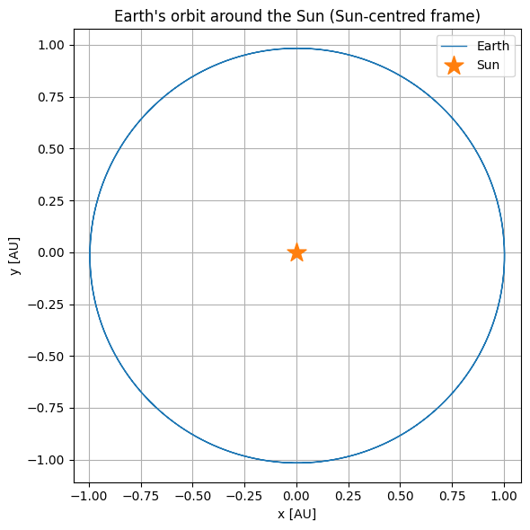

```python
# C1: Earth's orbit around the Sun (2-body run)
# Plotted in the Sun-centred frame (Earth position minus Sun position)
# so the Sun sits at the origin and the ellipse is easy to read.

plt.figure(figsize=(6, 6))

plt.plot(
    (r_earth_2b[:, 0] - r_sun_2b[:, 0]) / AU,
    (r_earth_2b[:, 1] - r_sun_2b[:, 1]) / AU,
    color="tab:blue",
    linewidth=1,
    label="Earth"
)

plt.scatter(
    0, 0,
    color="tab:orange",
    marker="*",
    s=250,
    label="Sun",
    zorder=3
)

plt.xlabel("x [AU]")
plt.ylabel("y [AU]")
plt.title("Earth's orbit around the Sun (Sun-centred frame)")

plt.axis("equal")
plt.legend()
plt.grid(True)
plt.tight_layout()
plt.show()
```

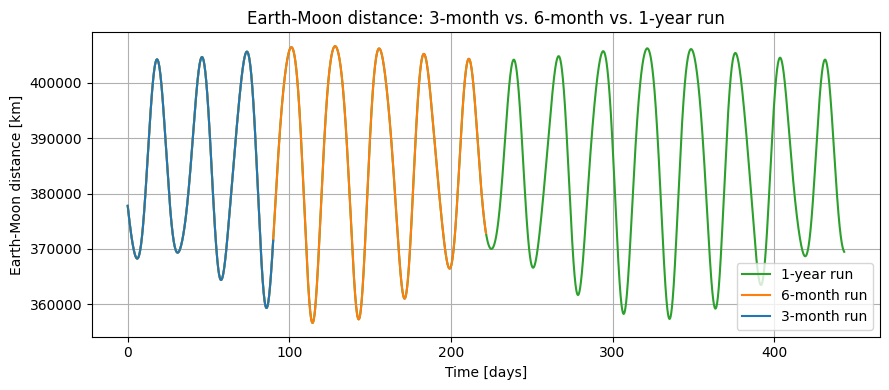

```python
# C1: Earth-Moon distance, 3-month vs. 6-month vs. 1-year run

earth_moon_distance_3b = np.linalg.norm(moon_rel_earth, axis=1)
earth_moon_distance_6b = np.linalg.norm(r_moon_6b - r_earth_6b, axis=1)
earth_moon_distance_1y = np.linalg.norm(moon_rel_earth_1y, axis=1)

plt.figure(figsize=(9, 4))

plt.plot(t_1y / DAY, earth_moon_distance_1y / 1e3,
         label="1-year run", color="tab:green")
plt.plot(t_6b / DAY, earth_moon_distance_6b / 1e3,
         label="6-month run", color="tab:orange")
plt.plot(t_3b / DAY, earth_moon_distance_3b / 1e3,
         label="3-month run", color="tab:blue")

plt.xlabel("Time [days]")
plt.ylabel("Earth-Moon distance [km]")
plt.title("Earth-Moon distance: 3-month vs. 6-month vs. 1-year run")

plt.legend()
plt.grid(True)
plt.tight_layout()
plt.show()
```

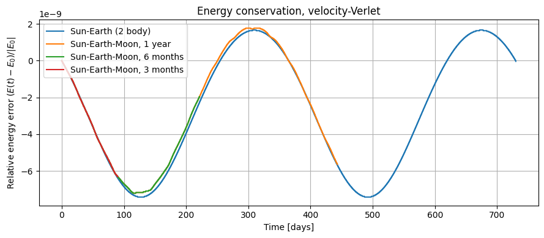

```python
# C1: relative energy error against time for all runs

E0_2b = diag_2b["E"].iloc[0]
rel_err_2b = (diag_2b["E"] - E0_2b) / abs(E0_2b)

E0_3b = diag_3b["E"].iloc[0]
rel_err_3b = (diag_3b["E"] - E0_3b) / abs(E0_3b)

E0_6b = diag_6b["E"].iloc[0]
rel_err_6b = (diag_6b["E"] - E0_6b) / abs(E0_6b)

E0_1y = diag_1y["E"].iloc[0]
rel_err_1y = (diag_1y["E"] - E0_1y) / abs(E0_1y)

plt.figure(figsize=(9, 4))

plt.plot(diag_2b["t"] / DAY, rel_err_2b, label="Sun-Earth (2 body)")
plt.plot(diag_1y["t"] / DAY, rel_err_1y, label="Sun-Earth-Moon, 1 year")
plt.plot(diag_6b["t"] / DAY, rel_err_6b, label="Sun-Earth-Moon, 6 months")
plt.plot(diag_3b["t"] / DAY, rel_err_3b, label="Sun-Earth-Moon, 3 months")

plt.xlabel("Time [days]")
plt.ylabel(r"Relative energy error $(E(t)-E_0)/|E_0|$")
plt.title("Energy conservation, velocity-Verlet")

plt.legend()
plt.grid(True)
plt.tight_layout()
plt.show()
```

### C2) One-year comparison against Horizons

Integrate the full 2026 snapshot for exactly one year and compare your final positions, body by body, with `bodies_2027-09-01.dat`.

Deliver:

- a **figure** showing the state of the system: the positions of all bodies in the ecliptic plane at the start and after one year (two panels, or one panel with two marker styles). Use a scale on which the inner planets are visible, and say which bodies fall outside it;
- a **table** of $‖𝐫sim−𝐫Horizons‖$ per body for **at least three time steps** spanning a factor 10 or more;
- a **figure** of those discrepancies (bar chart, logarithmic vertical axis, one group of bars per body).

Then discuss: relative to what scale is an error small, for each body? Which bodies improve when you halve $Δt$ and which do not, and what does that tell you about where the remaining error comes from?

*A question to take to the oral:* the snapshots give the outer planets as system barycentres with system masses (see the data cell). Estimate what the one-year discrepancy of Jupiter, and of Pluto whose moon Charon carries 11% of the system mass, would have been with planet-*centre* states instead, and why no time step could have fixed it.

**Results (C2):**

- **System at the start and after one year:** Figure 1 shows the system at the start and after one year. The $±2$ AU scale shows the Sun through Mars clearly, while Jupiter, Saturn, Uranus, Neptune, and Pluto lie outside this range and are therefore not visible.
- **Effect of time step:** as $Δt$ is reduced from 24 h to 6 h to 1 h, the position errors of most bodies decrease, showing that numerical integration error is an important source of the discrepancy with Horizons. Jupiter is a clear example: its error decreases from $1.09×109$ m to $7.84×103$ m and then to $4.29×102$ m.
- **Fast inner bodies:** even at $Δt=1$ h, the largest errors are found for the fast inner bodies: Mercury ($4.7×106$ m), the Moon (about $106$ m), Venus (about $4.5×105$ m), and Earth (about $105$ m). These bodies have shorter orbital periods, so a fixed time step represents a larger fraction of their orbital motion. Small numerical errors can therefore accumulate into a larger along-track, or phase, error over one year. Mercury's eccentric orbit also means that its acceleration changes more rapidly, particularly near perihelion. The discrepancy therefore tends to be larger for bodies with faster orbital motion.
- **Outer bodies:** in contrast, Pluto does not improve from 6 h to 1 h (138.5 m $→$ 138.5 m), while Neptune changes only slightly (67.5 m $→$ 66.6 m). The Sun also shows a similar plateau at a few hundred metres. This suggests that, for these bodies, reducing the time step is no longer the dominant way to reduce the discrepancy. Other effects, such as differences between the modelled initial conditions and the Horizons reference data or the representation of planetary positions relative to their barycentres, may become more important.
- **Error relative to orbital size:** the absolute errors should also be compared with each body's orbital radius. At $Δt=1$ h, the error is about $4.7×106$ m for Mercury, $4.3×102$ m for Jupiter, and 23 m for Uranus. Relative to their orbital radii, these correspond to approximately $8×10−5$, $5.5×10−10$, and $8×10−12$, respectively. Thus, even Mercury's largest 1 h error is well below $0.01%$ of its orbital radius, while the outer planets have extremely small relative position errors.
- **Overall:** reducing $Δt$ generally decreases the numerical integration error and improves agreement with Horizons. However, the remaining discrepancies at $Δt=1$ h show that the time step is not the only source of error. The comparison therefore demonstrates both the importance of time-step selection and the need to consider the initial conditions and reference-data representation when interpreting differences from Horizons.

```python
# C2: load data and calculate one-year discrepancies

import numpy as np
import pandas as pd
import matplotlib.pyplot as plt

AU = 1.495978707e11


# ---------- Read snapshot files ----------

def read_snapshot(filename):
    bodies = []
    positions = []

    with open(filename, "r") as f:
        for line in f:
            line = line.strip()

            if not line or line.startswith("#"):
                continue

            parts = line.split()

            # File format:
            # id  name  mass  x  y  z  vx  vy  vz

            bodies.append(parts[1])

            positions.append([
                float(parts[3]),  # x
                float(parts[4]),  # y
                float(parts[5])   # z
            ])

    return bodies, np.array(positions)


# Initial snapshot: 2026-09-01
bodies_initial, r_initial = read_snapshot(
    "data/bodies_2026-09-01.dat"
)

# Horizons reference: 2027-09-01
bodies_horizons, r_horizons = read_snapshot(
    "data/bodies_2027-09-01.dat"
)


# ---------- Read final simulation positions ----------

def read_final_positions(filename):

    df = pd.read_csv(filename)

    # Select the final time step
    final = df[df["step"] == df["step"].max()]

    # Sort by simulation body index
    final = final.sort_values("body")

    positions = final[["x", "y", "z"]].to_numpy()

    return positions


r_24h = read_final_positions(
    "data/C2/trajectory_24h.csv"
)

r_6h = read_final_positions(
    "data/C2/trajectory_6h.csv"
)

r_1h = read_final_positions(
    "data/C2/trajectory_1h.csv"
)


# ---------- Check number of bodies ----------

print("Number of Horizons bodies:", len(bodies_horizons))
print("Number of simulated bodies:", len(r_24h))

assert len(bodies_horizons) == len(r_24h)
assert len(bodies_horizons) == len(r_6h)
assert len(bodies_horizons) == len(r_1h)


# ---------- Calculate position discrepancies ----------

error_24h = np.linalg.norm(
    r_24h - r_horizons,
    axis=1
)

error_6h = np.linalg.norm(
    r_6h - r_horizons,
    axis=1
)

error_1h = np.linalg.norm(
    r_1h - r_horizons,
    axis=1
)


# ---------- Create table ----------

error_table = pd.DataFrame({
    "Body": bodies_horizons,
    "24 h [m]": error_24h,
    "6 h [m]": error_6h,
    "1 h [m]": error_1h
})

error_table
```

```
Number of Horizons bodies: 12
Number of simulated bodies: 12
```

|  | Body | 24 h [m] | 6 h [m] | 1 h [m] |
| --- | --- | --- | --- | --- |
| 0 | Sun | 8.875696e+05 | 2.808553e+02 | 2.307792e+02 |
| 1 | Mercury | 6.369524e+09 | 1.751489e+08 | 4.701529e+06 |
| 2 | Venus | 3.351999e+09 | 1.955484e+07 | 4.500708e+05 |
| 3 | Earth | 2.646012e+09 | 6.112246e+06 | 1.187136e+05 |
| 4 | Moon | 2.294810e+09 | 3.139011e+07 | 9.456758e+05 |
| 5 | Mars | 2.097260e+09 | 1.142670e+06 | 6.083537e+03 |
| 6 | Jupiter | 1.085921e+09 | 7.838124e+03 | 4.289634e+02 |
| 7 | Saturn | 8.512844e+08 | 1.130794e+03 | 1.203446e+02 |
| 8 | Uranus | 5.820862e+08 | 7.706015e+01 | 2.325105e+01 |
| 9 | Neptune | 4.727237e+08 | 6.751297e+01 | 6.655825e+01 |
| 10 | Pluto | 4.495019e+08 | 1.385403e+02 | 1.385403e+02 |
| 11 | Apophis | 3.086396e+09 | 5.622109e+06 | 9.538581e+04 |

[output not shown]

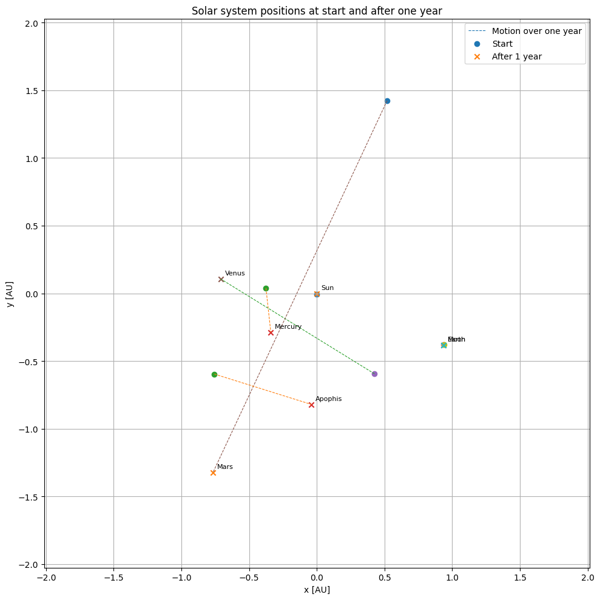

```
Bodies outside the ±2 AU plotting range:
Jupiter
Saturn
Uranus
Neptune
Pluto
```

```python
# C2: plot the system at the start and after one year

plt.figure(figsize=(10, 10))

# Plot each body's trajectory from start to final position
for body, r0, r1 in zip(bodies_initial, r_initial, r_1h):

    x0 = r0[0] / AU
    y0 = r0[1] / AU

    x1 = r1[0] / AU
    y1 = r1[1] / AU

    # Line showing movement
    plt.plot(
        [x0, x1],
        [y0, y1],
        linestyle="--",
        linewidth=0.8
    )

    # Start position
    plt.scatter(
        x0,
        y0,
        marker="o"
    )

    # Final position
    plt.scatter(
        x1,
        y1,
        marker="x"
    )

    # Label the final position
    plt.annotate(
        body,
        (x1, y1),
        xytext=(5, 5),
        textcoords="offset points",
        fontsize=8
    )

plt.xlabel("x [AU]")
plt.ylabel("y [AU]")
plt.title("Solar system positions at start and after one year")

plt.legend(
    ["Motion over one year", "Start", "After 1 year"]
)

plt.axis("equal")

# Focus on inner solar system
plt.xlim(-2, 2)
plt.ylim(-2, 2)

plt.grid(True)
plt.tight_layout()
plt.show()


# List bodies outside the plotting range

print("Bodies outside the ±2 AU plotting range:")

for body, pos in zip(bodies_initial, r_1h):

    x = pos[0] / AU
    y = pos[1] / AU

    if abs(x) > 2 or abs(y) > 2:
        print(body)
```

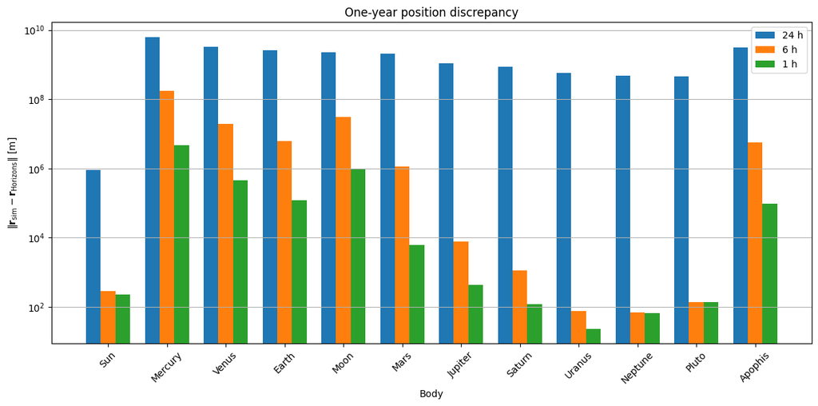

```python
# C2: plot one-year position discrepancies

x = np.arange(len(bodies_horizons))
width = 0.25

plt.figure(figsize=(12, 6))

plt.bar(
    x - width,
    error_24h,
    width,
    label="24 h"
)

plt.bar(
    x,
    error_6h,
    width,
    label="6 h"
)

plt.bar(
    x + width,
    error_1h,
    width,
    label="1 h"
)

plt.yscale("log")

plt.xlabel("Body")
plt.ylabel(r"$\|\mathbf{r}_{\mathrm{sim}}-\mathbf{r}_{\mathrm{Horizons}}\|$ [m]")
plt.title("One-year position discrepancy")

plt.xticks(
    x,
    bodies_horizons,
    rotation=45
)

plt.legend()
plt.grid(True, axis="y")
plt.tight_layout()
plt.show()
```

### C3) Conservation tests

Run the full system for one year with **both** integrators at **at least four** time steps each.

Deliver:

- a **table**: for every integrator and time step, the largest relative drift over the run in $E$, in $‖𝐋‖$, and in the centre-of-mass velocity;
- a **figure**, log-log, of the energy error against $Δt$ for both integrators, with the fitted slopes stated in the legend or the text;
- a **figure** of the relative energy error against *time* at one common time step for both integrators, chosen to show the qualitative difference between them.

State the observed orders and whether they match what you predicted in A3 and A4. Explain the behaviour of $‖𝐋‖$ and of the centre of mass: which of them is a property of the integrator, and which of the way you wrote the force loop?

*Results (C3):* observed orders — energy error $∝Δt2.0$ for velocity-Verlet, $∝Δt0.7$ for Euler-forward.

- **Energy vs. $Δt$.** Verlet's max energy error scales as $Δt1.99$ (2.2e-6 → 3.5e-8 from 1 to 0.125 day), matching A4's $O(Δt2)$. Euler is 3-5 orders worse throughout (8.7e-3 → 2.0e-3), slope 0.71 — shallower than the predicted $O(Δt)$ since the coarser steps aren't yet in the asymptotic regime relative to Mercury's 88-day orbit.
- **Error vs. time ($Δt=1$ day).** Verlet oscillates in a bounded band around zero, as predicted; Euler drifts monotonically all year — a secular error, not an oscillation.
- **Angular momentum — refines A4.** Verlet conserves $‖L‖$ to round-off at every $Δt$. Euler does **not**: it drifts $O(Δt)$ (6.7e-4 → 9.4e-5). Cause: one Euler step adds $Δt2∑imivi×ai$, a term Newton's third law doesn't cancel and that Verlet's symmetric update does. So an $L$ drift signals broken force symmetry only for Verlet — for Euler it's expected. (A4's table corrected.)
- **COM velocity.** The $10−6$–$10−5$ drift shown is identical for both integrators and doesn't shrink with $Δt$ — it's finite-difference round-off from differentiating the limited-precision $Rcom$ column, not physics. True momentum conservation is exact and integrator-independent, as A4 predicted.

|  | Integrator | dt [days] | Max \|ΔE/E0\| | Max \|Δ\|L\| / L0\| | Max \|ΔVcom/Vcom0\| |
| --- | --- | --- | --- | --- | --- |
| 0 | euler | 1.000 | 8.678899e-03 | 0.000667 | 0.000003 |
| 1 | euler | 0.500 | 5.558843e-03 | 0.000351 | 0.000003 |
| 2 | euler | 0.250 | 3.381936e-03 | 0.000183 | 0.000008 |
| 3 | euler | 0.125 | 1.963461e-03 | 0.000094 | 0.000015 |
| 4 | verlet | 1.000 | 2.234325e-06 | 0.000000 | 0.000003 |
| 5 | verlet | 0.500 | 5.651701e-07 | 0.000000 | 0.000003 |
| 6 | verlet | 0.250 | 1.417217e-07 | 0.000000 | 0.000008 |
| 7 | verlet | 0.125 | 3.544304e-08 | 0.000000 | 0.000015 |

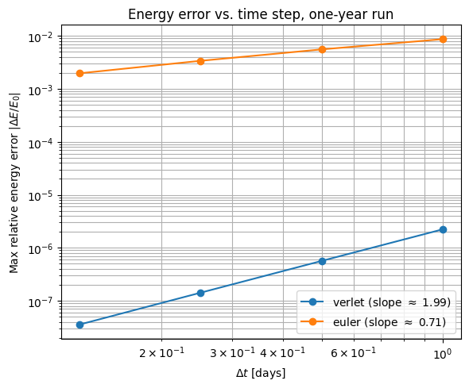

```
Fitted slope, velocity-Verlet: 1.99
Fitted slope, Euler-forward:   0.71
```

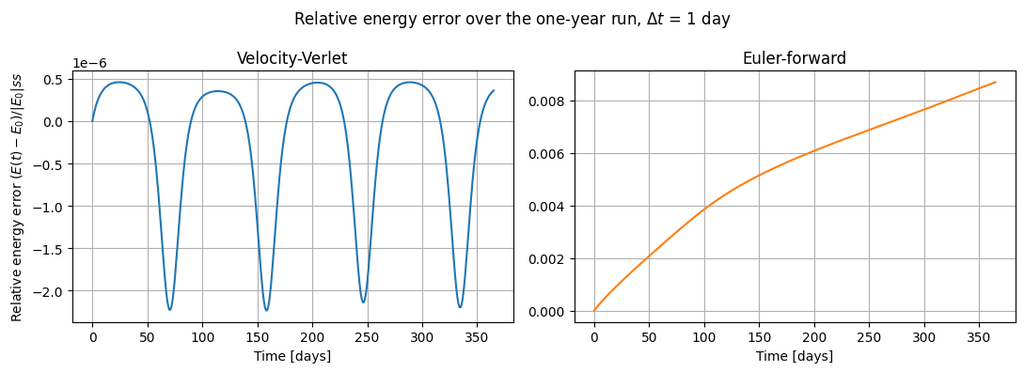

```python
# C3: drift table; energy error vs dt (log-log) with fitted slopes; error vs time

import numpy as np
import pandas as pd
import matplotlib.pyplot as plt

DAY = 86400.0

INTEGRATORS = ["verlet", "euler"]
DT_LABELS = ["1day", "0.5day", "0.25day", "0.125day"]
DT_DAYS = {"1day": 1.0, "0.5day": 0.5, "0.25day": 0.25, "0.125day": 0.125}


def load_diag(integrator, label):
    return pd.read_csv(f"data/C3/diagnostics_{integrator}_{label}.csv")


diagnostics = {(integ, label): load_diag(integ, label)
               for integ in INTEGRATORS for label in DT_LABELS}


# ---------- Drift table ----------
# For each run: the largest relative deviation from the t=0 value, over
# the whole one-year run, of E, ||L||, and the centre-of-mass velocity.
# Vcom is not stored directly; we recover it from the finite difference
# of the stored Rcom (both integrators conserve linear momentum from the
# same antisymmetric force loop, so Vcom should be constant regardless
# of integrator).

rows = []

for integ in INTEGRATORS:
    for label in DT_LABELS:
        d = diagnostics[(integ, label)]
        t = d["t"].to_numpy()

        E0 = d["E"].iloc[0]
        rel_E = (d["E"] - E0) / abs(E0)

        L_norm = np.sqrt(d["Lx"]**2 + d["Ly"]**2 + d["Lz"]**2)
        L0 = L_norm.iloc[0]
        rel_L = (L_norm - L0) / abs(L0)

        Rcom = d[["Rcom_x", "Rcom_y", "Rcom_z"]].to_numpy()
        Vcom = np.gradient(Rcom, t, axis=0)
        v_norm = np.linalg.norm(Vcom, axis=1)
        rel_V = (v_norm - v_norm[0]) / abs(v_norm[0])

        rows.append({
            "Integrator": integ,
            "dt [days]": DT_DAYS[label],
            "Max |ΔE/E0|": np.abs(rel_E).max(),
            "Max |Δ|L| / L0|": np.abs(rel_L).max(),
            "Max |ΔVcom/Vcom0|": np.abs(rel_V).max(),
        })

drift_table = pd.DataFrame(rows).sort_values(
    ["Integrator", "dt [days]"], ascending=[True, False]
).reset_index(drop=True)
display(drift_table)


# ---------- Figure: energy error vs dt (log-log), fitted slopes ----------

plt.figure(figsize=(6, 5))

slopes = {}
for integ, color in [("verlet", "tab:blue"), ("euler", "tab:orange")]:
    sub = drift_table[drift_table["Integrator"] == integ].sort_values("dt [days]")
    dt_vals = sub["dt [days]"].to_numpy()
    err_vals = sub["Max |ΔE/E0|"].to_numpy()

    slope, _ = np.polyfit(np.log(dt_vals), np.log(err_vals), 1)
    slopes[integ] = slope

    plt.loglog(dt_vals, err_vals, "o-", color=color,
                label=f"{integ} (slope $\\approx$ {slope:.2f})")

plt.xlabel(r"$\Delta t$ [days]")
plt.ylabel(r"Max relative energy error $|\Delta E/E_0|$")
plt.title("Energy error vs. time step, one-year run")
plt.legend()
plt.grid(True, which="both")
plt.tight_layout()
plt.show()

print(f"Fitted slope, velocity-Verlet: {slopes['verlet']:.2f}")
print(f"Fitted slope, Euler-forward:   {slopes['euler']:.2f}")


# ---------- Figure: relative energy error vs time, common dt ----------
# dt = 1 day (the coarsest, shared by both integrators) makes the
# qualitative difference clearest: Euler's secular drift is largest here,
# while velocity-Verlet is still bounded.

common_label = "1day"
d_v = diagnostics[("verlet", common_label)]
d_e = diagnostics[("euler", common_label)]

rel_E_v = (d_v["E"] - d_v["E"].iloc[0]) / abs(d_v["E"].iloc[0])
rel_E_e = (d_e["E"] - d_e["E"].iloc[0]) / abs(d_e["E"].iloc[0])

fig, (ax1, ax2) = plt.subplots(1, 2, figsize=(11, 4), sharex=True)

ax1.plot(d_v["t"] / DAY, rel_E_v, color="tab:blue")
ax1.set_xlabel("Time [days]")
ax1.set_ylabel(r"Relative energy error $(E(t)-E_0)/|E_0|ss$")
ax1.set_title("Velocity-Verlet")
ax1.grid(True)

ax2.plot(d_e["t"] / DAY, rel_E_e, color="tab:orange")
ax2.set_xlabel("Time [days]")
ax2.set_title("Euler-forward")
ax2.grid(True)

fig.suptitle(f"Relative energy error over the one-year run, $\\Delta t$ = {DT_DAYS[common_label]:g} day")
fig.tight_layout()
plt.show()
```

### C4) Long-time stability

Simulate Sun, Jupiter, Saturn, Uranus, Neptune and Pluto for 200,000 days (about 548 years) with velocity-Verlet.

Deliver:

- a **figure** of the orbits in the ecliptic plane over the whole run;
- a **figure** of the invariants against time (energy, and $‖𝐋‖$ or the centre-of-mass motion);
- a **table** of the smallest and largest distance to the Sun reached by each planet during the run, next to its literature perihelion and aphelion.

Then judge the result: do the orbits stay closed and bounded, or is there a systematic trend? Does the energy error grow with time, and is that consistent with what you found in C3? Explain how a symplectic integrator can accumulate a phase error along the orbit while the energy stays bounded.

*Results (C4):*

[figure not shown]

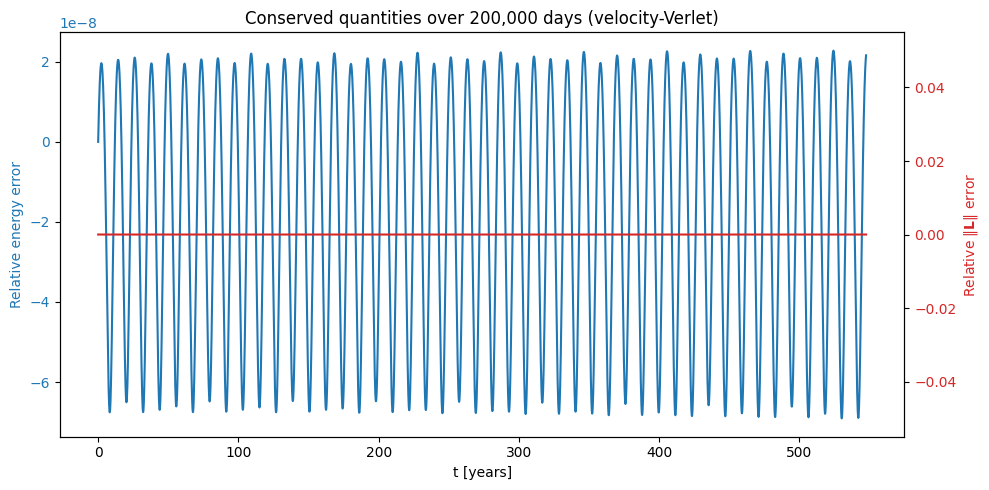

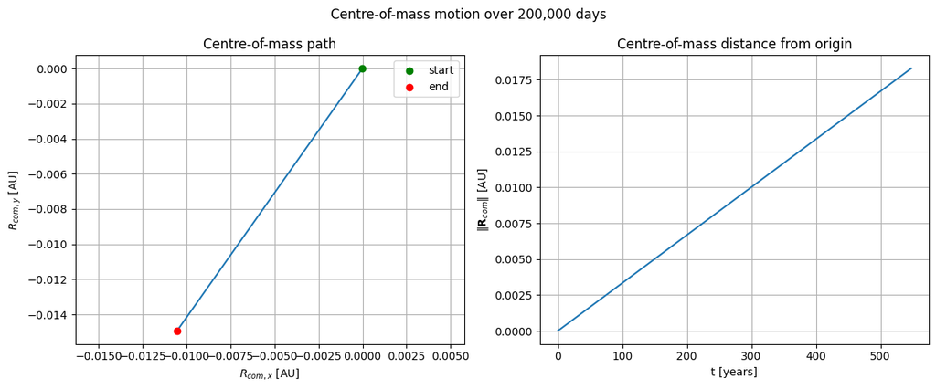

|  | Body | Sim. perihelion [AU] | Lit. perihelion [AU] | Peri. error [%] | Sim. aphelion [AU] | Lit. aphelion [AU] | Aph. error [%] |
| --- | --- | --- | --- | --- | --- | --- | --- |
| 0 | Jupiter | 4.940784 | 4.950 | -0.186187 | 5.463188 | 5.458 | 0.095053 |
| 1 | Saturn | 9.008624 | 9.041 | -0.358098 | 10.080209 | 10.124 | -0.432547 |
| 2 | Uranus | 18.252317 | 18.286 | -0.184202 | 20.121122 | 20.096 | 0.125012 |
| 3 | Neptune | 29.792098 | 29.810 | -0.060053 | 30.360323 | 30.330 | 0.099977 |
| 4 | Pluto | 29.646939 | 29.658 | -0.037295 | 49.354083 | 49.305 | 0.099551 |

```python
# C4: outer solar system orbits; invariants and COM motion vs time; perihelion/aphelion table

import numpy as np
import pandas as pd
import matplotlib.pyplot as plt

AU = 1.495978707e11

# ---------- Load trajectory and diagnostics ----------

traj = pd.read_csv("data/C4/trajectory.csv")
diag = pd.read_csv("data/C4/diagnostics.csv")

# Order matches --bodies Sun,Jupiter,Saturn,Uranus,Neptune,Pluto
body_names = ["Sun", "Jupiter", "Saturn", "Uranus", "Neptune", "Pluto"]

# Literature perihelion/aphelion (NASA planetary fact sheet), in AU
literature = {
    "Jupiter": (4.950, 5.458),
    "Saturn":  (9.041, 10.124),
    "Uranus":  (18.286, 20.096),
    "Neptune": (29.81, 30.33),
    "Pluto":   (29.658, 49.305),
}


# ---------- Figure: orbits in the ecliptic plane ----------

plt.figure(figsize=(9, 9))

for i, name in enumerate(body_names):
    b = traj[traj["body"] == i]

    if name == "Sun":
        # The Sun's own orbit (around the barycentre) is far too small to
        # see on this scale, so mark it as a single big point instead of
        # a line.
        plt.scatter(
            b["x"] / AU, b["y"] / AU,
            s=120, color="gold", edgecolor="black",
            zorder=5, label="Sun"
        )
    else:
        plt.plot(b["x"] / AU, b["y"] / AU, linewidth=0.6, label=name)

plt.xlabel("x [AU]")
plt.ylabel("y [AU]")
plt.title("Outer solar system orbits over 200,000 days (~548 years)")
plt.axis("equal")
plt.legend()
plt.grid(True)
plt.tight_layout()
plt.show()


# ---------- Figure: invariants against time ----------

t_years = diag["t"] / (365.25 * 86400)

E0 = diag["E"].iloc[0]
L_norm = np.sqrt(diag["Lx"]**2 + diag["Ly"]**2 + diag["Lz"]**2)
L0 = L_norm.iloc[0]

rel_E_error = (diag["E"] - E0) / abs(E0)
rel_L_error = (L_norm - L0) / abs(L0)

fig, ax1 = plt.subplots(figsize=(10, 5))

ax1.plot(t_years, rel_E_error, color="tab:blue", label="Relative energy error")
ax1.set_xlabel("t [years]")
ax1.set_ylabel("Relative energy error", color="tab:blue")
ax1.tick_params(axis="y", labelcolor="tab:blue")

ax2 = ax1.twinx()
ax2.plot(t_years, rel_L_error, color="tab:red", label="Relative |L| error")
ax2.set_ylabel(r"Relative $\|\mathbf{L}\|$ error", color="tab:red")
ax2.tick_params(axis="y", labelcolor="tab:red")

plt.title("Conserved quantities over 200,000 days (velocity-Verlet)")
fig.tight_layout()
plt.show()


# ---------- Figure: centre-of-mass motion ----------

Rcom_x_au = diag["Rcom_x"] / AU
Rcom_y_au = diag["Rcom_y"] / AU
Rcom_norm_au = np.sqrt(diag["Rcom_x"]**2 + diag["Rcom_y"]**2 + diag["Rcom_z"]**2) / AU

fig, (ax1, ax2) = plt.subplots(1, 2, figsize=(12, 5))

ax1.plot(Rcom_x_au, Rcom_y_au)
ax1.scatter(Rcom_x_au.iloc[0], Rcom_y_au.iloc[0], color="green", label="start", zorder=5)
ax1.scatter(Rcom_x_au.iloc[-1], Rcom_y_au.iloc[-1], color="red", label="end", zorder=5)
ax1.set_xlabel("$R_{com,x}$ [AU]")
ax1.set_ylabel("$R_{com,y}$ [AU]")
ax1.set_title("Centre-of-mass path")
ax1.axis("equal")
ax1.legend()
ax1.grid(True)

ax2.plot(t_years, Rcom_norm_au)
ax2.set_xlabel("t [years]")
ax2.set_ylabel(r"$\|\mathbf{R}_{com}\|$ [AU]")
ax2.set_title("Centre-of-mass distance from origin")
ax2.grid(True)

fig.suptitle("Centre-of-mass motion over 200,000 days")
fig.tight_layout()
plt.show()


# ---------- Table: perihelion/aphelion vs literature ----------

sun = traj[traj["body"] == 0][["step", "x", "y", "z"]].set_index("step")

rows = []

for i, name in enumerate(body_names):
    if name == "Sun":
        continue

    b = traj[traj["body"] == i][["step", "x", "y", "z"]].set_index("step")

    r_rel = b[["x", "y", "z"]].to_numpy() - sun.loc[b.index, ["x", "y", "z"]].to_numpy()
    dist = np.linalg.norm(r_rel, axis=1) / AU

    sim_peri = dist.min()
    sim_aph = dist.max()
    lit_peri, lit_aph = literature[name]

    rows.append({
        "Body": name,
        "Sim. perihelion [AU]": sim_peri,
        "Lit. perihelion [AU]": lit_peri,
        "Peri. error [%]": 100 * (sim_peri - lit_peri) / lit_peri,
        "Sim. aphelion [AU]": sim_aph,
        "Lit. aphelion [AU]": lit_aph,
        "Aph. error [%]": 100 * (sim_aph - lit_aph) / lit_aph,
    })

peri_aph_table = pd.DataFrame(rows)
peri_aph_table
```

### C5) The Apophis 2029 close approach

Integrate the full system from the 2026 epoch through April 2029 with velocity-Verlet, and determine the **date and the miss distance** (Earth centre to Apophis) of the closest approach.

Deliver:

- a **table**: for each time step you ran, the miss distance and the date and time of closest approach; the value you obtain in the limit $Δt→0$ (extrapolate, and say how); and the JPL Horizons value with its source;
- a **figure** of the Earth-Apophis distance against time around the encounter, with one curve per time step, and the radius of the geostationary ring (42,164 km) drawn as a reference line;
- a **number** from one control run: the miss distance you get when the Moon is left out of the simulation. Explain the size of the difference; it is larger than the Moon's own pull on Apophis, so what dominates?

Then discuss what limits the accuracy of your prediction: integration error, or model error (bodies you do not include, effects you do not model)? Support your answer with evidence from your own runs rather than assertion, and state which effect you would add first if you had to improve the prediction.

*Practical hints:* the encounter is fast. Make sure your output cadence around April 2029 is fine enough to resolve the minimum, or better, detect the minimum in code. Think about which bodies must be in the simulation for the approach to come out right.

*Results (C5):* closest approach on 2029-04-13 at 21:46 TDB, extrapolated miss distance ≈ 38,020 km (Horizons/CNEOS: ≈ 38,000 km, same time, https://cneos.jpl.nasa.gov/ca/).

|  | Run | dt [s] | Closest approach (TDB) | Miss distance [km] |
| --- | --- | --- | --- | --- |
| 0 | 2 h | 7200 | 2029-04-13 21:48 | 40201.9 |
| 1 | 1 h | 3600 | 2029-04-13 21:46 | 38548.3 |
| 2 | 30 min | 1800 | 2029-04-13 21:46 | 38157.7 |
| 3 | 15 min | 900 | 2029-04-13 21:46 | 38057.1 |

```
Successive difference ratios (expect ~4 for 2nd-order convergence): [4.23 3.88]
Richardson extrapolation (dt -> 0): 38023.6 km
Quadratic fit extrapolation (dt -> 0): 38016.8 km
JPL Horizons reference: ~38000 km on 2029-04-13 21:46 TDB (CNEOS close-approach data, https://cneos.jpl.nasa.gov/ca/)
```

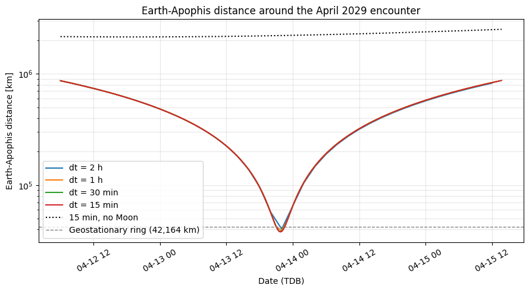

```
With Moon  (dt=15 min):    38057.1 km at 2029-04-13 21:46:05.430886716
No Moon    (dt=15 min):  2147101.6 km at 2029-04-12 19:15:48.262954742
Shift from omitting the Moon: 2,109,045 km
```

```python
# C5: distance vs time around the encounter for several dt; convergence table

import numpy as np
import pandas as pd
import matplotlib.pyplot as plt
from IPython.display import display

AU = 1.495978707e11
EPOCH = pd.Timestamp("2026-09-01")
GEO_RING_KM = 42164.0

# JPL Horizons / CNEOS close-approach data (https://cneos.jpl.nasa.gov/ca/):
# 2029-04-13 21:46 TDB, geocentric distance ~38,000 km.
HORIZONS_DATE = pd.Timestamp("2029-04-13 21:46:00")
HORIZONS_DIST_KM = 38000.0

# Full-system runs, all velocity-Verlet, 2026-09-01 -> 2029-06-01.
# body indices follow the input-file order: 0 Sun ... 3 Earth ... 11 Apophis.
runs = {
    "2 h":    ("data/C5/trajectory_dt2h.csv",    3, 11, 7200),
    "1 h":    ("data/C5/trajectory_dt1h.csv",    3, 11, 3600),
    "30 min": ("data/C5/trajectory_dt30min.csv", 3, 11, 1800),
    "15 min": ("data/C5/trajectory_dt15min.csv", 3, 11, 900),
}


def load_earth_apophis(path, earth_idx, apophis_idx):
    df = pd.read_csv(path, usecols=["t", "body", "x", "y", "z"])
    earth = df[df["body"] == earth_idx].sort_values("t")
    apophis = df[df["body"] == apophis_idx].sort_values("t")
    t = earth["t"].to_numpy()
    r_earth = earth[["x", "y", "z"]].to_numpy()
    r_apophis = apophis[["x", "y", "z"]].to_numpy()
    return t, np.linalg.norm(r_apophis - r_earth, axis=1)


def refine_minimum(t, dist):
    # Parabolic interpolation through the discrete minimum and its two
    # neighbours gives a sub-timestep estimate of the true closest approach.
    i = int(np.argmin(dist))
    if i == 0 or i == len(dist) - 1:
        return t[i], dist[i]
    t0, t1, t2 = t[i - 1], t[i], t[i + 1]
    d0, d1, d2 = dist[i - 1], dist[i], dist[i + 1]
    denom = d0 - 2 * d1 + d2
    if denom == 0:
        return t1, d1
    step = t1 - t0
    delta = 0.5 * (d0 - d2) / denom
    return t1 + delta * step, d1 - 0.25 * (d0 - d2) * delta


results = {}
for label, (path, ei, ai, dt) in runs.items():
    t, dist = load_earth_apophis(path, ei, ai)
    t_min, d_min = refine_minimum(t, dist)
    results[label] = dict(dt=dt, t=t, dist=dist, t_min=t_min, d_min=d_min,
                           date=EPOCH + pd.to_timedelta(float(t_min), unit="s"))


# ---------- Table: miss distance and date per time step ----------

table = pd.DataFrame([
    {"Run": label, "dt [s]": r["dt"],
     "Closest approach (TDB)": r["date"].strftime("%Y-%m-%d %H:%M"),
     "Miss distance [km]": round(r["d_min"] / 1e3, 1)}
    for label, r in results.items()
])
display(table)


# ---------- Convergence order and dt -> 0 extrapolation ----------
# velocity-Verlet has global error O(dt^2), so successive differences in
# the miss distance should shrink by a factor of ~4 each time dt halves.

dts = np.array([results[l]["dt"] for l in runs], dtype=float)
d_mins = np.array([results[l]["d_min"] for l in runs], dtype=float)

diffs = -np.diff(d_mins)
ratios = diffs[:-1] / diffs[1:]
print(f"Successive difference ratios (expect ~4 for 2nd-order convergence): {np.round(ratios, 2)}")

# Richardson extrapolation from the two finest runs (dt halves, ratio 4 for
# a 2nd-order method): D0 = D(h) + (D(h) - D(2h)) / (4 - 1)
d_extrap = d_mins[-1] + (d_mins[-1] - d_mins[-2]) / 3
print(f"Richardson extrapolation (dt -> 0): {d_extrap/1e3:.1f} km")

# Cross-check: least-squares fit of miss distance against dt^2 using all
# four runs
A = np.vstack([np.ones_like(dts), dts**2]).T
(D0, C), *_ = np.linalg.lstsq(A, d_mins, rcond=None)
print(f"Quadratic fit extrapolation (dt -> 0): {D0/1e3:.1f} km")

print(f"JPL Horizons reference: ~{HORIZONS_DIST_KM:.0f} km on "
      f"{HORIZONS_DATE.strftime('%Y-%m-%d %H:%M')} TDB "
      "(CNEOS close-approach data, https://cneos.jpl.nasa.gov/ca/)")


# ---------- Control run: Moon excluded ----------

t_nm, dist_nm = load_earth_apophis("data/C5/trajectory_dt15min_noMoon.csv", 3, 10)
t_min_nm, d_min_nm = refine_minimum(t_nm, dist_nm)
date_min_nm = EPOCH + pd.to_timedelta(float(t_min_nm), unit="s")
d_with_moon = results["15 min"]["d_min"]


# ---------- Figure: distance vs time around the encounter, incl. no-Moon ----------
# Log scale and a wider window, since omitting the Moon shifts the
# encounter by more than a day and almost two orders of magnitude in
# distance (see below).

center = results["15 min"]["date"]
window = pd.Timedelta(hours=40)

plt.figure(figsize=(9, 5))
for label, r in results.items():
    dates = EPOCH + pd.to_timedelta(r["t"], unit="s")
    mask = (dates >= center - window) & (dates <= center + window)
    plt.plot(dates[mask], r["dist"][mask] / 1e3, label=f"dt = {label}")

dates_nm = EPOCH + pd.to_timedelta(t_nm, unit="s")
mask_nm = (dates_nm >= center - window) & (dates_nm <= center + window)
plt.plot(dates_nm[mask_nm], dist_nm[mask_nm] / 1e3, label="15 min, no Moon",
          color="black", linestyle=":")

plt.axhline(GEO_RING_KM, color="gray", linestyle="--", linewidth=1,
            label=f"Geostationary ring ({GEO_RING_KM:,.0f} km)")

plt.yscale("log")
plt.xlabel("Date (TDB)")
plt.ylabel("Earth-Apophis distance [km]")
plt.title("Earth-Apophis distance around the April 2029 encounter")
plt.legend()
plt.grid(True, which="both", alpha=0.3)
plt.xticks(rotation=30)
plt.tight_layout()
plt.show()

print(f"With Moon  (dt=15 min): {d_with_moon/1e3:10.1f} km at {results['15 min']['date']}")
print(f"No Moon    (dt=15 min): {d_min_nm/1e3:10.1f} km at {date_min_nm}")
print(f"Shift from omitting the Moon: {(d_min_nm - d_with_moon)/1e3:,.0f} km")
```

## Lessons learned

What would you do differently if you started over? What surprised you? What in your results still bothers you?

## Hand-in

One zip per group, layout exactly:

```
<group>_A1.zip
├── A1.ipynb     this notebook, filled in and executed
│                (all outputs present; task cells untouched)
├── A1.html      python3 nb2html.py A1.ipynb
├── code/        all .c/.h (incl. vec3d.h) + README.md with build/run
│                instructions; no binaries
└── data/        all data files this notebook loads: your outputs AND
                 the provided snapshots, so the notebook runs as handed in
```

Long runs are done in the terminal; record the exact commands in the *Build & run log* and let the notebook load the saved output from `data/`. Handed in executed, the notebook must open and display without rerunning anything.

**Before you submit,** check your own zip:

```
python3 check_my_submission.py <group>_A1.zip --release A1.ipynb
```

where `--release` is a freshly downloaded, unmodified `A1.ipynb`. It verifies the layout, that the task cells are untouched, that every cell has been executed, that your C code compiles, and that every path and link in the notebook is relative and present in the zip. Fix what it reports, then submit.